# Analise de gastos de parlamentares do congresso

Rodolfo Viana

15-04-2015

```r
library(dplyr)
```

```r
library(ggplot2)
```

Ao analisar o documento de cota para exercicio da ativdade parlamentar, é possivel notar que algumas despesas são negativas ou tem o valor igual a zero. O que em outros casos poderia significar algum erro nos dados, nesse caso especifico, isso acontece pois se trata de um bilhete de compensação. Significa que foi emitido um bilhete e não foi utilizado pelo deputado. O caso de despesa negativa ocorre para a emissão de bilhete aéreo. Já o caso de despesa igual a zero ocorre quando o tipo é telefonia, o que significa que a despesa foi franqueada.

Já que apenas um tipo de despesa pode ter valor negativo o mais indicado é que se tenha maior atenação para esse tipo de depensa, pois algumas metricas serão “prejudicadas”, como por exemplo, media, desvio padrão, variancia. Seria interesante tambem fazer dois tipos de analise, uma com todos os valores e uma segunda analise retirando os valores negativos.

Um outro fator que chamou minha atenação foi a quantidade de partidos politicos que tem representantes eleitos, um total de 28. Alem disso, existe deputados sem partidos. Falta descorbrir se isso é realmente possivel ou se é algum erro nos dados.

As despesas podem ser de 17 tipos diferentes.

```r
file <- read.csv("AnoAtual.csv")
itemDescricao <- select(file, txtDescricao, numSubCota)
itemDescricaoOrder <- itemDescricao[!duplicated(itemDescricao),]
itemDescricaoOrder <- itemDescricaoOrder[order(itemDescricaoOrder$numSubCota), ]
colnames(itemDescricaoOrder) <- c("Despesa", "Tipo")
itemDescricaoOrder
```

```
##                                                         Despesa Tipo
## 25577 MANUTENÇÃO DE ESCRITÓRIO DE APOIO À ATIVIDADE PARLAMENTAR    1
## 69                                COMBUSTÍVEIS E LUBRIFICANTES.    3
## 11713             CONSULTORIAS  PESQUISAS E TRABALHOS TÉCNICOS.    4
## 12069                      DIVULGAÇÃO DA ATIVIDADE PARLAMENTAR.    5
## 29261  SERVIÇO DE SEGURANÇA PRESTADO POR EMPRESA ESPECIALIZADA.    8
## 28475                                          PASSAGENS AÉREAS    9
## 40268                                                 TELEFONIA   10
## 33246                                          SERVIÇOS POSTAIS   11
## 1                                     ASSINATURA DE PUBLICAÇÕES   12
## 18143                FORNECIMENTO DE ALIMENTAÇÃO DO PARLAMENTAR   13
## 24040    HOSPEDAGEM  EXCETO DO PARLAMENTAR NO DISTRITO FEDERAL.   14
## 24771                        LOCAÇÃO OU FRETAMENTO DE AERONAVES  119
## 24826             LOCAÇÃO OU FRETAMENTO DE VEÍCULOS AUTOMOTORES  120
## 24813                      LOCAÇÃO OU FRETAMENTO DE EMBARCAÇÕES  121
## 29387                 SERVIÇO DE TÁXI  PEDÁGIO E ESTACIONAMENTO  122
## 29135               PASSAGENS TERRESTRES  MARÍTIMAS OU FLUVIAIS  123
## 13009                                     Emissão Bilhete Aéreo  999
```

É possivel notar que os nossos parlamentares gastam mais recuros da cota nos itens: **DIVULGAÇÃO DA ATIVIDADE PARLAMENTAR**, **LOCAÇÃO OU FRETAMENTO DE VEÍCULOS AUTOMOTORES** e **MANUTENÇÃO DE ESCRITÓRIO DE APOIO À ATIVIDADE PARLAMENTAR**

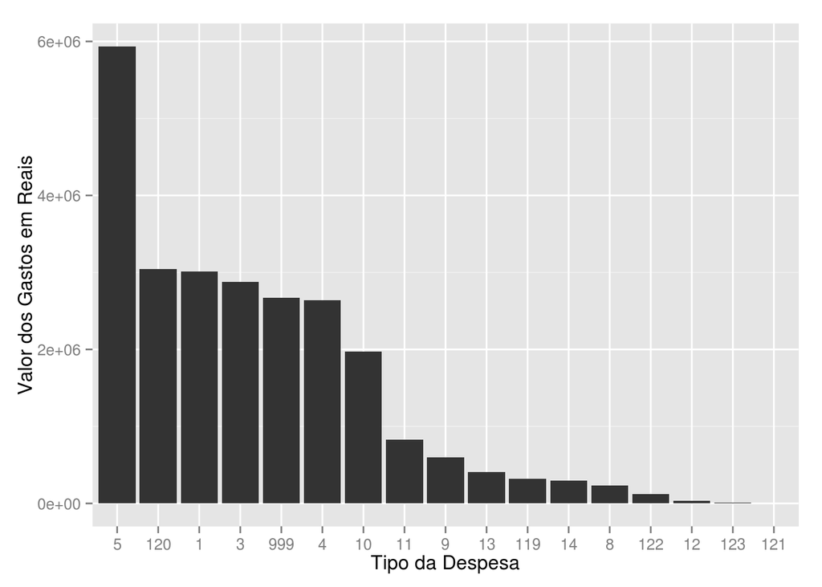

```r
groupedByNumSubCota <- group_by(file, numSubCota)
valorLiquido <- summarise(groupedByNumSubCota, sum(vlrLiquido))
colnames(valorLiquido) <- c("Tipo", "Descricao")
valorLiquido <- valorLiquido[order(valorLiquido$Descricao), ]
valorLiquido$Tipo <- as.character(valorLiquido$Tipo)
ggplot(valorLiquido, aes(x=reorder(Tipo, -Descricao), y=Descricao)) + geom_bar(stat = "identity") + labs(x='Tipo da Despesa', y='Valor dos Gastos em Reais')
```

Os tipos de despesas que mais variam e que portanto são mais desiguais são: **DIVULGAÇÃO DA ATIVIDADE PARLAMENTAR**, **CONSULTORIAS PESQUISAS E TRABALHOS TÉCNICOS** e **LOCAÇÃO OU FRETAMENTO DE AERONAVES**

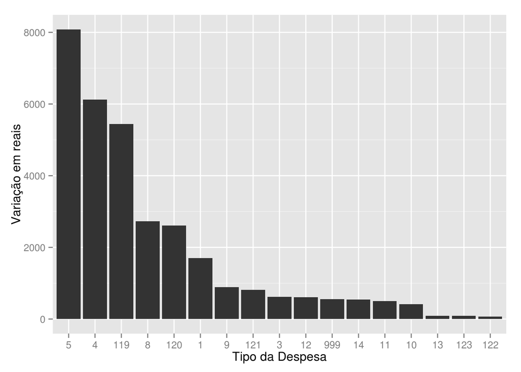

```r
desvio <- summarise(groupedByNumSubCota, sd(vlrLiquido))
colnames(desvio) <- c("Tipo", "Desvio")
desvio$Tipo <- as.character(desvio$Tipo)
ggplot(desvio, aes(x=reorder(Tipo, -Desvio), y=Desvio)) + geom_bar(stat = "identity") + labs(x='Tipo da Despesa', y='Variação em reais')
```

O valor ficou alto para esses tipos de despesas pois a variação dos valores dos gastos dessas despesas são altos. Quanto mais proximo de zero mais uniforme são os gastos.

Fonte do documento: http://www2.camara.leg.br/transparencia/cota-para-exercicio-da-atividade-parlamentar/dados-abertos-cota-parlamentar

Mais explicações sobre o documento: http://www2.camara.leg.br/transparencia/cota-para-exercicio-da-atividade-parlamentar/explicacoes-sobre-o-formato-dos-arquivos-xml